# AIML_ML_Project_full_code_notebook (1)

## Problem Statement

### Context

AllLife Bank is a US bank that has a growing customer base. The majority of these customers are liability customers (depositors) with varying sizes of deposits. The number of customers who are also borrowers (asset customers) is quite small, and the bank is interested in expanding this base rapidly to bring in more loan business and in the process, earn more through the interest on loans. In particular, the management wants to explore ways of converting its liability customers to personal loan customers (while retaining them as depositors).

A campaign that the bank ran last year for liability customers showed a healthy conversion rate of over 9% success. This has encouraged the retail marketing department to devise campaigns with better target marketing to increase the success ratio.

You as a Data scientist at AllLife bank have to build a model that will help the marketing department to identify the potential customers who have a higher probability of purchasing the loan.

### Objective

To predict whether a liability customer will buy personal loans, to understand which customer attributes are most significant in driving purchases, and identify which segment of customers to target more.

### Data Dictionary

- `ID`: Customer ID
- `Age`: Customer’s age in completed years
- `Experience`: #years of professional experience
- `Income`: Annual income of the customer (in thousand dollars)
- `ZIP Code`: Home Address ZIP code.
- `Family`: the Family size of the customer
- `CCAvg`: Average spending on credit cards per month (in thousand dollars)
- `Education`: Education Level. 1: Undergrad; 2: Graduate;3: Advanced/Professional
- `Mortgage`: Value of house mortgage if any. (in thousand dollars)
- `Personal_Loan`: Did this customer accept the personal loan offered in the last campaign? (0: No, 1: Yes)
- `Securities_Account`: Does the customer have securities account with the bank? (0: No, 1: Yes)
- `CD_Account`: Does the customer have a certificate of deposit (CD) account with the bank? (0: No, 1: Yes)
- `Online`: Do customers use internet banking facilities? (0: No, 1: Yes)
- `CreditCard`: Does the customer use a credit card issued by any other Bank (excluding All life Bank)? (0: No, 1: Yes)

## Importing necessary libraries

```python
# Installing the libraries with the specified version.
!pip install numpy==1.25.2 pandas==1.5.3 matplotlib==3.7.1 seaborn==0.13.1 scikit-learn==1.2.2 sklearn-pandas==2.2.0 -q --user
```

**Note**:

1. After running the above cell, kindly restart the notebook kernel (for Jupyter Notebook) or runtime (for Google Colab), write the relevant code for the project from the next cell, and run all cells sequentially from the next cell.
2. On executing the above line of code, you might see a warning regarding package dependencies. This error message can be ignored as the above code ensures that all necessary libraries and their dependencies are maintained to successfully execute the code in this notebook.

```python
import pandas as pd
import numpy as np

# libraries helps with data visualization
import matplotlib.pyplot as plt
import seaborn as sns
sns.set_theme()

#libraries to help data processing
import matplotlib.patches as mpatches
from matplotlib.ticker import FuncFormatter

#Remove the limit for number of displayed columns
pd.set_option("display.max_columns", None)
#Remove the limit for number of displayed rows
pd.set_option("display.max_rows", 200)

#Library to split data
from sklearn.model_selection import train_test_split

# to built modelfor prediction
from sklearn.tree import DecisionTreeClassifier
from sklearn import tree

# to tune different models
from sklearn.model_selection import GridSearchCV

# to get different matrics scores
from sklearn.metrics import(
    f1_score,
    accuracy_score,
    recall_score,
    precision_score,
    confusion_matrix,
    make_scorer,
    classification_report
)
#suppress warnings
import warnings
warnings.filterwarnings('ignore')
```

## Loading the dataset

```python
# get colab access my google drive
from google.colab import drive
drive.mount('/content/drive')
```

```python
#Read the dataset Loan modelling.csv file from drive
df_original = pd.read_csv('/content/drive/MyDrive/Colab Notebooks/MachineLearning/Loan_Modelling.csv')

# create a copy of original dataframe to avoid modifying the original dataframe
df=df_original.copy()
```

## Data Overview

- Observations
- Sanity checks

```python
#Get number of rows and columns in the data using shape attribute
rows,columns=df.shape
print(f"This dataset has {rows} rows and {columns} columns")
```

```
This dataset has 5000 rows and 14 columns
```

```python
#Retrive the summary information of dataframe
df.info()
```

```
<class 'pandas.core.frame.DataFrame'>
RangeIndex: 5000 entries, 0 to 4999
Data columns (total 14 columns):
 #   Column              Non-Null Count  Dtype
---  ------              --------------  -----
 0   ID                  5000 non-null   int64
 1   Age                 5000 non-null   int64
 2   Experience          5000 non-null   int64
 3   Income              5000 non-null   int64
 4   ZIPCode             5000 non-null   int64
 5   Family              5000 non-null   int64
 6   CCAvg               5000 non-null   float64
 7   Education           5000 non-null   int64
 8   Mortgage            5000 non-null   int64
 9   Personal_Loan       5000 non-null   int64
 10  Securities_Account  5000 non-null   int64
 11  CD_Account          5000 non-null   int64
 12  Online              5000 non-null   int64
 13  CreditCard          5000 non-null   int64
dtypes: float64(1), int64(13)
memory usage: 547.0 KB
```

**This dataset has 5000 rows and 14 columns**

```python
#Retrive first 5 rows of dataset
print("First 5 Rows of dataset")
print(df.head(5).to_string(index=False))

# Retrive last 5 rows of dataset
print("\nLast 5 Rows of dataset")
print(df.tail(5).to_string(index=False))
```

```
First 5 Rows of dataset
 ID  Age  Experience  Income  ZIPCode  Family  CCAvg  Education  Mortgage  Personal_Loan  Securities_Account  CD_Account  Online  CreditCard
  1   25           1      49    91107       4    1.6          1         0              0                   1           0       0           0
  2   45          19      34    90089       3    1.5          1         0              0                   1           0       0           0
  3   39          15      11    94720       1    1.0          1         0              0                   0           0       0           0
  4   35           9     100    94112       1    2.7          2         0              0                   0           0       0           0
  5   35           8      45    91330       4    1.0          2         0              0                   0           0       0           1

Last 5 Rows of dataset
  ID  Age  Experience  Income  ZIPCode  Family  CCAvg  Education  Mortgage  Personal_Loan  Securities_Account  CD_Account  Online  CreditCard
4996   29           3      40    92697       1    1.9          3         0              0                   0           0       1           0
4997   30           4      15    92037       4    0.4          1        85              0                   0           0       1           0
4998   63          39      24    93023       2    0.3          3         0              0                   0           0       0           0
4999   65          40      49    90034       3    0.5          2         0              0                   0           0       1           0
5000   28           4      83    92612       3    0.8          1         0              0                   0           0       1           1
```

```python
#check if there is any missing value
missing_values=df.isnull().sum()
# check for nulls and Nans values in the dataset
print('Null values' + str(df.isnull().sum())+'\n')
print('Nan values' + str(df.isna().sum())+'\n')

if missing_values.sum()==0:
  print('There are no missing values in the dataset')
else:
  print('There are missing values in the dataset')
```

```
Null valuesID                    0
Age                   0
Experience            0
Income                0
ZIPCode               0
Family                0
CCAvg                 0
Education             0
Mortgage              0
Personal_Loan         0
Securities_Account    0
CD_Account            0
Online                0
CreditCard            0
dtype: int64

Nan valuesID                    0
Age                   0
Experience            0
Income                0
ZIPCode               0
Family                0
CCAvg                 0
Education             0
Mortgage              0
Personal_Loan         0
Securities_Account    0
CD_Account            0
Online                0
CreditCard            0
dtype: int64

There are no missing values in the dataset
```

```python
# find zero or negative values in columns
columns_tocheck = ['Income','CCAvg','Mortgage','Securities_Account','CD_Account','Online','CreditCard']
for column in columns_tocheck:
    negative_values=df[df[column]<=0]
    print(f"number of non positive values in '{column}': {len(negative_values)}")
```

```
number of non positive values in 'Income': 0
number of non positive values in 'CCAvg': 106
number of non positive values in 'Mortgage': 3462
number of non positive values in 'Securities_Account': 4478
number of non positive values in 'CD_Account': 4698
number of non positive values in 'Online': 2016
number of non positive values in 'CreditCard': 3530
```

```python
#Retrive full statistics of dataset
df.describe(include='all').T
```

|  | count | mean | std | min | 25% | 50% | 75% | max |
| --- | --- | --- | --- | --- | --- | --- | --- | --- |
| ID | 5000.0 | 2500.500000 | 1443.520003 | 1.0 | 1250.75 | 2500.5 | 3750.25 | 5000.0 |
| Age | 5000.0 | 45.338400 | 11.463166 | 23.0 | 35.00 | 45.0 | 55.00 | 67.0 |
| Experience | 5000.0 | 20.104600 | 11.467954 | -3.0 | 10.00 | 20.0 | 30.00 | 43.0 |
| Income | 5000.0 | 73.774200 | 46.033729 | 8.0 | 39.00 | 64.0 | 98.00 | 224.0 |
| ZIPCode | 5000.0 | 93169.257000 | 1759.455086 | 90005.0 | 91911.00 | 93437.0 | 94608.00 | 96651.0 |
| Family | 5000.0 | 2.396400 | 1.147663 | 1.0 | 1.00 | 2.0 | 3.00 | 4.0 |
| CCAvg | 5000.0 | 1.937938 | 1.747659 | 0.0 | 0.70 | 1.5 | 2.50 | 10.0 |
| Education | 5000.0 | 1.881000 | 0.839869 | 1.0 | 1.00 | 2.0 | 3.00 | 3.0 |
| Mortgage | 5000.0 | 56.498800 | 101.713802 | 0.0 | 0.00 | 0.0 | 101.00 | 635.0 |
| Personal_Loan | 5000.0 | 0.096000 | 0.294621 | 0.0 | 0.00 | 0.0 | 0.00 | 1.0 |
| Securities_Account | 5000.0 | 0.104400 | 0.305809 | 0.0 | 0.00 | 0.0 | 0.00 | 1.0 |
| CD_Account | 5000.0 | 0.060400 | 0.238250 | 0.0 | 0.00 | 0.0 | 0.00 | 1.0 |
| Online | 5000.0 | 0.596800 | 0.490589 | 0.0 | 0.00 | 1.0 | 1.00 | 1.0 |
| CreditCard | 5000.0 | 0.294000 | 0.455637 | 0.0 | 0.00 | 0.0 | 1.00 | 1.0 |

```python
# Drop the ID column from dataset as we can see there no use.
if 'ID' in df.columns:
  df.drop('ID',axis=1,inplace=True)

# Retrive Top 5 records from dataset after dropping ID column
print(df.head(5).to_string(index=False))
```

```
 Age  Experience  Income  ZIPCode  Family  CCAvg  Education  Mortgage  Personal_Loan  Securities_Account  CD_Account  Online  CreditCard
  25           1      49    91107       4    1.6          1         0              0                   1           0       0           0
  45          19      34    90089       3    1.5          1         0              0                   1           0       0           0
  39          15      11    94720       1    1.0          1         0              0                   0           0       0           0
  35           9     100    94112       1    2.7          2         0              0                   0           0       0           0
  35           8      45    91330       4    1.0          2         0              0                   0           0       0           1
```

```python
#find the correlation between variables in the database
df.corr()
```

|  | Age | Experience | Income | ZIPCode | Family | CCAvg | Education | Mortgage | Personal_Loan | Securities_Account | CD_Account | Online | CreditCard |
| --- | --- | --- | --- | --- | --- | --- | --- | --- | --- | --- | --- | --- | --- |
| Age | 1.000000 | 0.994215 | -0.055269 | -0.030530 | -0.046418 | -0.052012 | 0.041334 | -0.012539 | -0.007726 | -0.000436 | 0.008043 | 0.013702 | 0.007681 |
| Experience | 0.994215 | 1.000000 | -0.046574 | -0.030456 | -0.052563 | -0.050077 | 0.013152 | -0.010582 | -0.007413 | -0.001232 | 0.010353 | 0.013898 | 0.008967 |
| Income | -0.055269 | -0.046574 | 1.000000 | -0.030709 | -0.157501 | 0.645984 | -0.187524 | 0.206806 | 0.502462 | -0.002616 | 0.169738 | 0.014206 | -0.002385 |
| ZIPCode | -0.030530 | -0.030456 | -0.030709 | 1.000000 | 0.027512 | -0.012188 | -0.008266 | 0.003614 | -0.002974 | 0.002422 | 0.021671 | 0.028317 | 0.024033 |
| Family | -0.046418 | -0.052563 | -0.157501 | 0.027512 | 1.000000 | -0.109275 | 0.064929 | -0.020445 | 0.061367 | 0.019994 | 0.014110 | 0.010354 | 0.011588 |
| CCAvg | -0.052012 | -0.050077 | 0.645984 | -0.012188 | -0.109275 | 1.000000 | -0.136124 | 0.109905 | 0.366889 | 0.015086 | 0.136534 | -0.003611 | -0.006689 |
| Education | 0.041334 | 0.013152 | -0.187524 | -0.008266 | 0.064929 | -0.136124 | 1.000000 | -0.033327 | 0.136722 | -0.010812 | 0.013934 | -0.015004 | -0.011014 |
| Mortgage | -0.012539 | -0.010582 | 0.206806 | 0.003614 | -0.020445 | 0.109905 | -0.033327 | 1.000000 | 0.142095 | -0.005411 | 0.089311 | -0.005995 | -0.007231 |
| Personal_Loan | -0.007726 | -0.007413 | 0.502462 | -0.002974 | 0.061367 | 0.366889 | 0.136722 | 0.142095 | 1.000000 | 0.021954 | 0.316355 | 0.006278 | 0.002802 |
| Securities_Account | -0.000436 | -0.001232 | -0.002616 | 0.002422 | 0.019994 | 0.015086 | -0.010812 | -0.005411 | 0.021954 | 1.000000 | 0.317034 | 0.012627 | -0.015028 |
| CD_Account | 0.008043 | 0.010353 | 0.169738 | 0.021671 | 0.014110 | 0.136534 | 0.013934 | 0.089311 | 0.316355 | 0.317034 | 1.000000 | 0.175880 | 0.278644 |
| Online | 0.013702 | 0.013898 | 0.014206 | 0.028317 | 0.010354 | -0.003611 | -0.015004 | -0.005995 | 0.006278 | 0.012627 | 0.175880 | 1.000000 | 0.004210 |
| CreditCard | 0.007681 | 0.008967 | -0.002385 | 0.024033 | 0.011588 | -0.006689 | -0.011014 | -0.007231 | 0.002802 | -0.015028 | 0.278644 | 0.004210 | 1.000000 |

```python
#checking if there is any corretion between Education level and mortgage amount.
corr_M_E=df['Mortgage'].corr(df['Education'])
print(f"The correlation between Education level and mortgage amount is {corr_M_E}")
```

```
The correlation between Education level and mortgage amount is -0.033327124629950425
```

## Observations

General Data Observations

## Exploratory Data Analysis.

- EDA is an important part of any project involving data.
- It is important to investigate and understand the data better before building a model with it.
- A few questions have been mentioned below which will help you approach the analysis in the right manner and generate insights from the data.
- A thorough analysis of the data, in addition to the questions mentioned below, should be done.

**Questions**:

1. What is the distribution of mortgage attribute? Are there any noticeable patterns or outliers in the distribution?
2. How many customers have credit cards?
3. What are the attributes that have a strong correlation with the target attribute (personal loan)?
4. How does a customer's interest in purchasing a loan vary with their age?
5. How does a customer's interest in purchasing a loan vary with their education?

**Q 1. What is the distribution of mortgage attribute? Are there any noticeable patterns or outliers in the distribution?**

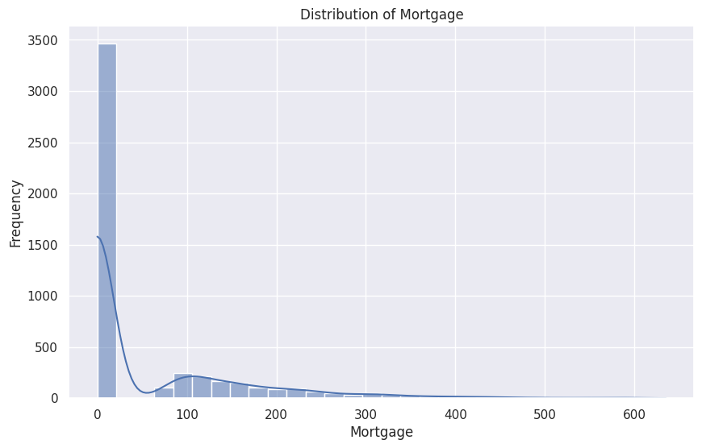

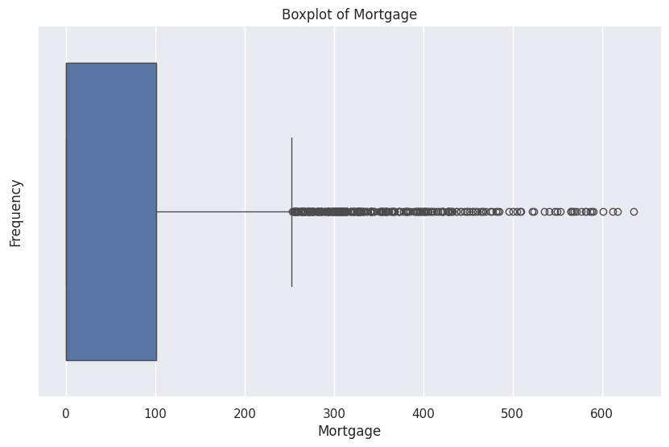

```python
#Plot the distribution mortgage using histplot
plt.figure(figsize=(10,6))
sns.histplot(df['Mortgage'], bins=30,kde=True)
plt.title('Distribution of Mortgage')
plt.xlabel('Mortgage')
plt.ylabel('Frequency')
plt.show()


# Plot the distribution of martgage using boxplot to identify outliers
plt.figure(figsize=(10,6))
sns.boxplot(df['Mortgage'],orient='h')
plt.title('Boxplot of Mortgage')
plt.xlabel('Mortgage')
plt.ylabel('Frequency')
plt.show()
```

- The data is right-skewed(positive), there are large no. of outliers on the higher end of mortgage value.
- This distribution suggests a strong need for transformation.

```python
# no. of customers with no mortgage
no_mortgage_count=df[df['Mortgage']==0].shape[0]
print(f"Number of customers with no mortgage: {no_mortgage_count}")
#total no. of customers
total_customers=df.shape[0]
print(f"Total number of customers: {total_customers}")
#Percentage of customer with no mortgage
percentage_no_mortgage=(no_mortgage_count/total_customers)*100
print(f"Percentage of customer with no mortgage: {percentage_no_mortgage:.2f}%")
```

```
Number of customers with no mortgage: 3462
Total number of customers: 5000
Percentage of customer with no mortgage: 69.24%
```

- 69.24% of customers do not have a mortgage, this is significant number within overall customer base. Recommendation-
- Market to these customers with a special program with low introductory rates to capture business.

**Q.2 How many customers have credit cards?**

```python
# total number of customers
total_customers=df.shape[0]
# no fo customers with credit cards fo all life bank and other banks
other_cc=df[df['CreditCard']==1].shape[0]
all_life_cc=df[df['CreditCard']==0].shape[0]

print(f"Total number of customers: {total_customers}")
print(f"Number of customers with credit cards for AllLife Bank: {all_life_cc}")
print(f"Number of customers with credit cards for other banks: {other_cc}")
```

```
Total number of customers: 5000
Number of customers with credit cards for AllLife Bank: 3530
Number of customers with credit cards for other banks: 1470
```

**Q.3 What are the attributes that have a strong correlation with the target attribute (personal loan)?**

```python
# find the highest correlated feature pairs in the person loan df dataframe
corr_matrix=df.corr(numeric_only=True)
# Unstack the correlation matrix
corr_pairs=corr_matrix.unstack()
# Filter out self correlation
filtered_corr=corr_pairs[corr_pairs!=1]
# Sort the correlation pairs in descending order
sorted_pairs=filtered_corr.sort_values(ascending=False)
#display the correlated feature pair
highest_corr_feature=sorted_pairs.head(10)
print(highest_corr_feature)
```

```
Age                 Experience            0.994215
Experience          Age                   0.994215
CCAvg               Income                0.645984
Income              CCAvg                 0.645984
Personal_Loan       Income                0.502462
Income              Personal_Loan         0.502462
CCAvg               Personal_Loan         0.366889
Personal_Loan       CCAvg                 0.366889
Securities_Account  CD_Account            0.317034
CD_Account          Securities_Account    0.317034
dtype: float64
```

```python
#Calculate the correlation matrix
corr_matrix=df.corr(numeric_only=True)
#get correlation with target attribute (Personal Loan)
corr_with_target=corr_matrix['Personal_Loan'].drop('Personal_Loan')
# Identify the attributes with the strong correlations
stron_corr=corr_with_target[corr_with_target.abs()>0.5]
#Print attributes with the strong correlations with the tager attributes
print("Atributes with the strong correlation with the target attribute (Personal Loan):")
for att, corr in stron_corr.items():
  print(f"{att}: {corr}")
```

```
Atributes with the strong correlation with the target attribute (Personal Loan):
Income: 0.502462292494936
```

- Income has a strong correlation with the target attribute Personal_Loan

**Q.4 How does a customer's interest in purchasing a loan vary with their age?**

```
Proportion of customers interested in loans by age group:
------------------------------------------------------------------------------------------------------------------------
Age_Group:20-30:, Proportion: 10.04%
Age_Group:30-40:, Proportion: 10.18%
Age_Group:40-50:, Proportion: 9.31%
Age_Group:50-60:, Proportion: 8.85%
Age_Group:60-70:, Proportion: 10.24%
```

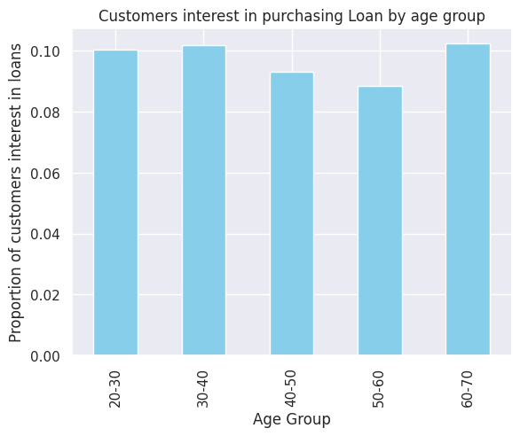

```python
#Create Age bins
age_bin=[20,30,40,50,60,70]
labels=['20-30','30-40','40-50','50-60','60-70']
df['Age_Group']=pd.cut(df['Age'],bins=age_bin,labels=labels,include_lowest=True,right=False)
#Calculate the propotion for customers interested in loans for each age group
interest_by_age=df.groupby('Age_Group')['Personal_Loan'].mean()
#Print proportion of customers interest in loans by age grp
print("Proportion of customers interested in loans by age group:")
print("--"*60)
for agegrp, proportion in interest_by_age.items():
  print(f"Age_Group:{agegrp}:, Proportion: {proportion*100:.2f}%")

#Visualization
interest_by_age.plot(kind='bar',color='skyblue')
plt.xlabel('Age Group')
plt.ylabel('Proportion of customers interest in loans')
plt.title( "Customers interest in purchasing Loan by age group")
plt.show()
```

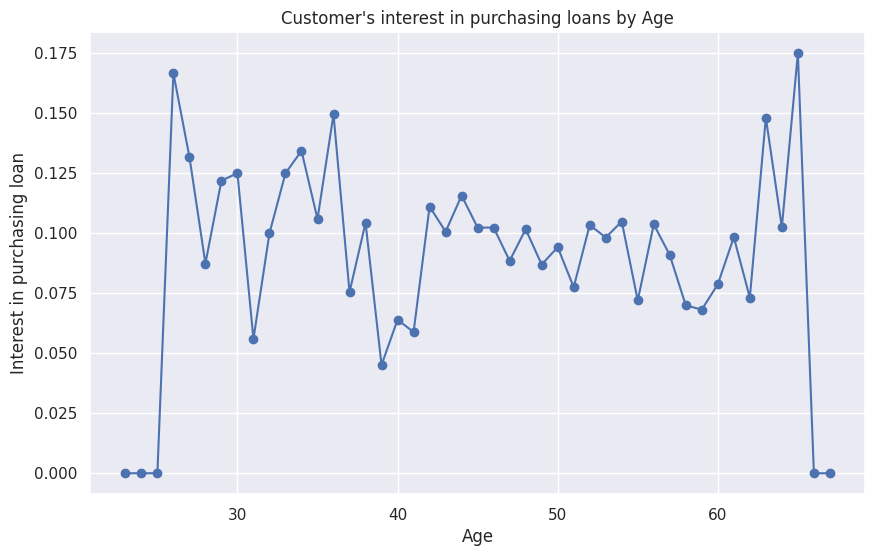

```python
# Groupby Age and calculate the mean interest in purchasing a loan.
age_interest_df=df.groupby('Age')['Personal_Loan'].mean().reset_index()
#Plot the result
plt.figure(figsize=(10,6))
plt.plot(age_interest_df['Age'],age_interest_df['Personal_Loan'],marker='o',linestyle='-',color='b')
plt.xlabel('Age')
plt.ylabel('Interest in purchasing loan')
plt.title("Customer's interest in purchasing loans by Age")
plt.grid(True)
plt.show()
```

- There is no significant difference between age groups that are interested in personal loan

**Q.5 How does a customer's interest in purchasing a loan vary with their education?**

```
Proportion of customers interest in loans by education level:
------------------------------------------------------------------------------------------------------------------------
Education Level: 1, Proportion: 4.44%
Education Level: 2, Proportion: 12.97%
Education Level: 3, Proportion: 13.66%
```

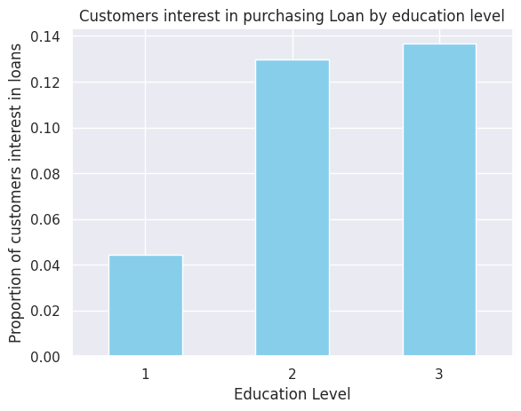

```python
# Calculate the proportion of customers interest in loans for each education level
loan_interest_by_education=df.groupby('Education')['Personal_Loan'].mean()

# Print the proportion of customers interest in loans by education level
# 1:- Undergrad, 2:- Graduate, 3:- Advanced/Professional
print("Proportion of customers interest in loans by education level:")
print("--"*60)
for education, proportion in loan_interest_by_education.items():
  print(f"Education Level: {education}, Proportion: {proportion*100:.2f}%")
#Visualization
loan_interest_by_education.plot(kind='bar',color='skyblue')
plt.xlabel('Education Level')
plt.ylabel('Proportion of customers interest in loans')
plt.title( "Customers interest in purchasing Loan by education level")
plt.xticks(rotation=0)
plt.show()
```

- Undergraduate at 4.44% is very low percentage interested in loans, This could be related to those indivisuals have student dept and not intersted in credit card expenses or high APR.

**Recommendation**:-

- A special program with low APR or a no interest rate penalty for a time period could interest this indiavidual.
- Both Graduated(12.97%) and Advanced/Professions(13.66%)are more interested in Personal loans. Thsi could be related to greater financial stability and money mangagement experience.

**Additional Questions**

**Q.6 What is the distribution of mortgage with or without credit cards?**

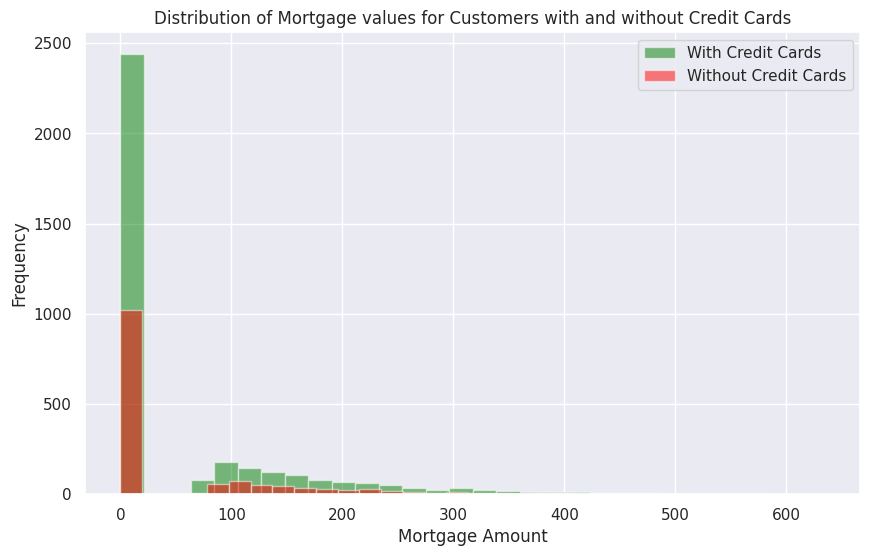

```python
#filter the dataframe for customers with and without credit cards
customers_with_credit_cards=df[df['CreditCard']==0]
customers_without_credit_cards=df[df['CreditCard']==1]
#Plot the distributio of mortgage values for customers with and without credit cards
plt.figure(figsize=(10,6))
#histogrma
plt.hist(customers_with_credit_cards['Mortgage'],bins=30,alpha=0.5,color='green',label='With Credit Cards')
plt.hist(customers_without_credit_cards['Mortgage'],bins=30,alpha=0.5,color='red',label='Without Credit Cards')
plt.xlabel('Mortgage Amount')
plt.ylabel('Frequency')
plt.title('Distribution of Mortgage values for Customers with and without Credit Cards')
plt.legend()
plt.show()
```

## Observations

- There is more even distribution across customers with credit cards but still
- lower compare to customers with credit cards.

**Q.7 Does average spedding on credit cards per month impact mortgage amount?**

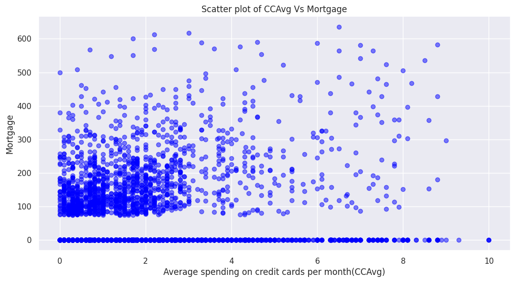

```python
#Create scatter plot for CCAvg VS Mortgage to identify any pattern.
plt.figure(figsize=(12,6))
plt.scatter(data=df,x='CCAvg',y='Mortgage',alpha=0.5,color='blue')
plt.title('Scatter plot of CCAvg Vs Mortgage')
plt.xlabel('Average spending on credit cards per month(CCAvg)')
plt.ylabel('Mortgage')
plt.grid(True)
plt.show()
```

## Observations

- The mejority of data point cluster in the lower left corner, indicating that lower average credit card spending is associate with lower mortage value
- There are less data points as average credit card soending increases, suggesting higher credit card spending doesnr necessarily correlate with higher mortage.

**Q.8 Does income impact mortage amount?**

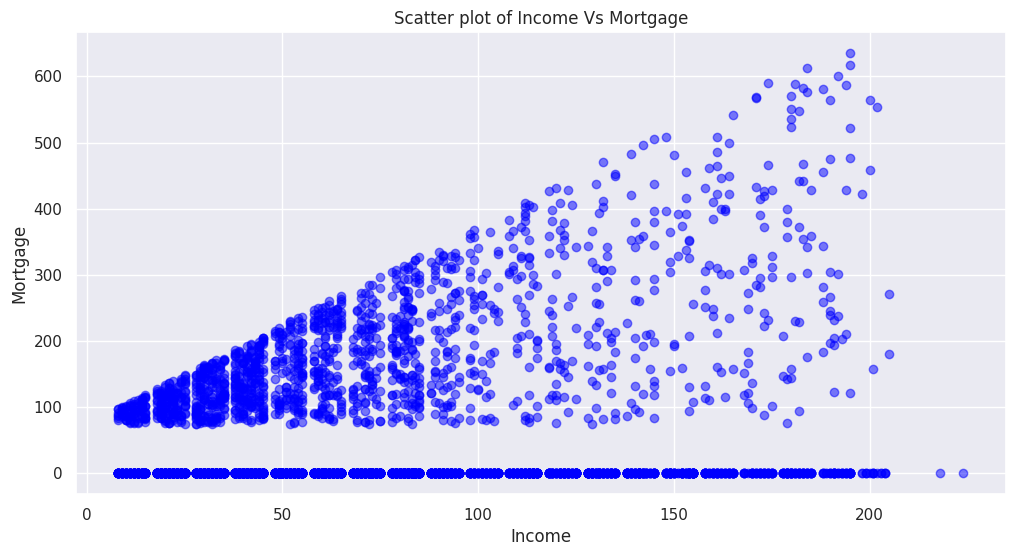

```python
#Create a scatter plot showing the relationship between income and mortgage
plt.figure(figsize=(12,6))
plt.scatter(data=df,x='Income',y='Mortgage',alpha=0.5,color='blue')
plt.title('Scatter plot of Income Vs Mortgage')
plt.xlabel('Income')
plt.ylabel("Mortgage")
plt.show()
```

## Observation

- There is a general positive correlation between Income and Mortgage, as income increases mortgage amount tends to increase as well.

**Q.9 Does income reflect higher or lower average credit card spending?**

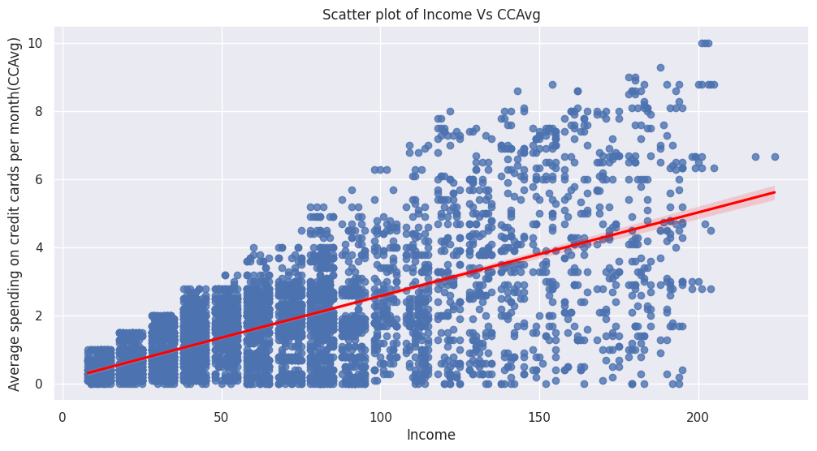

```python
#scatter plot of Income Vs CCAvg with regression line.
plt.figure(figsize=(12,6))
sns.regplot(data=df,x='Income',y='CCAvg',line_kws={'color':'red'})
plt.title('Scatter plot of Income Vs CCAvg')
plt.xlabel('Income')
plt.ylabel('Average spending on credit cards per month(CCAvg)')
plt.show()
```

**Observations**

**Q.10 What are all of the distributions?**

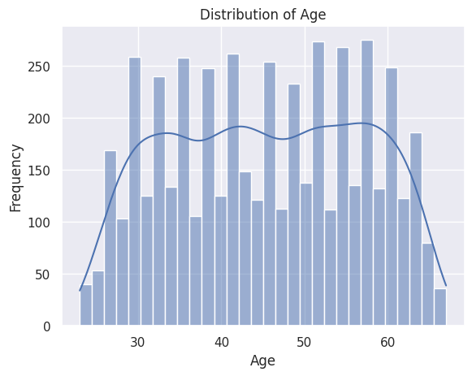

```python
#Age distribution
sns.histplot(df['Age'],bins=30,kde=True)
plt.title('Distribution of Age')
plt.xlabel('Age')
plt.ylabel('Frequency')
plt.show()
```

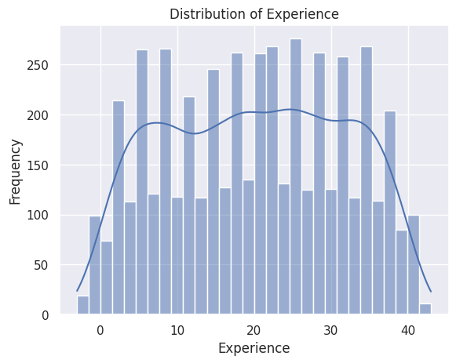

```python
#Experience distribution
sns.histplot(df['Experience'],bins=30,kde=True)
plt.title('Distribution of Experience')
plt.xlabel('Experience')
plt.ylabel('Frequency')
plt.show()
```

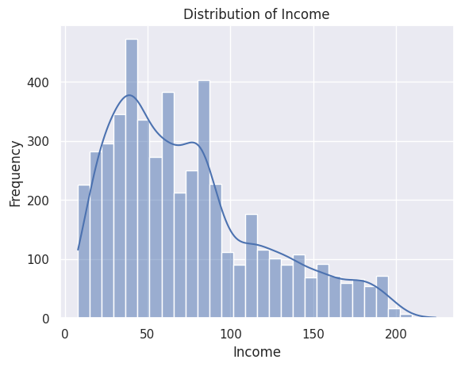

```python
#Income Ditribution
sns.histplot(df['Income'],bins=30,kde=True)
plt.title('Distribution of Income')
plt.xlabel('Income')
plt.ylabel('Frequency')
plt.show()
```

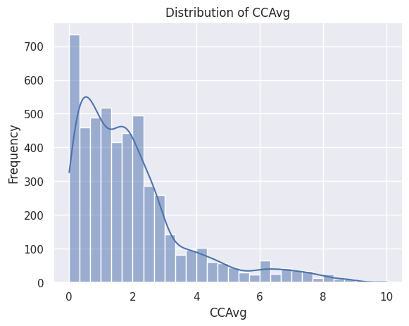

```python
# CCAvg Distribution
sns.histplot(df['CCAvg'],bins=30,kde=True)
plt.title('Distribution of CCAvg')
plt.xlabel('CCAvg')
plt.ylabel('Frequency')
plt.show()
```

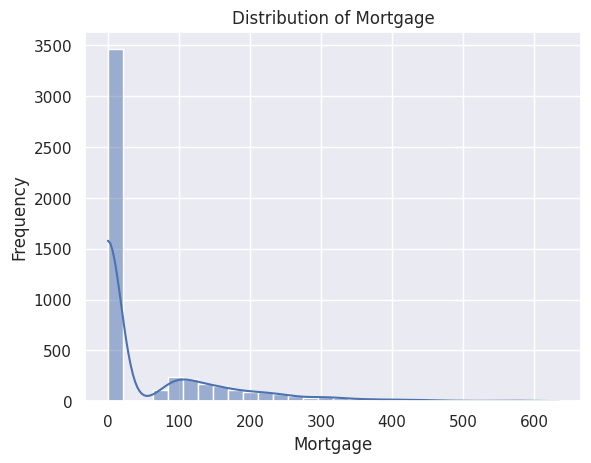

```python
#Mortgage Distribution
sns.histplot(df['Mortgage'],bins=30,kde=True)
plt.title('Distribution of Mortgage')
plt.xlabel('Mortgage')
plt.ylabel('Frequency')
plt.show()
```

**Q.11 Find the no. of customer who accepted and did not accepted the personal loan.**

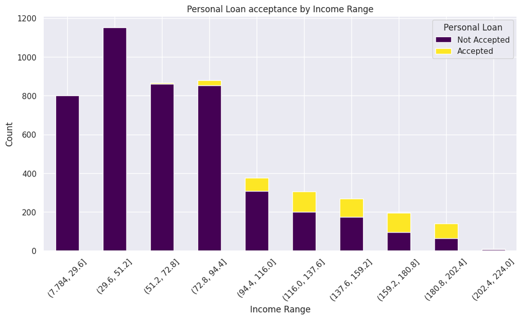

```python
#Bin the Income data into range
incomeBin=pd.cut(df['Income'],bins=10)
#Create a crosstab  to count the occurence of each personal_loan status within each income range.
income_loan_crosstab=pd.crosstab(incomeBin,df['Personal_Loan'])
# Plot the stacked bar plot
income_loan_crosstab.plot(kind='bar',stacked=True,colormap='viridis',figsize=(12,6))
plt.xlabel('Income Range')
plt.ylabel('Count')
plt.title('Personal Loan acceptance by Income Range')
plt.legend(title='Personal Loan',labels=['Not Accepted','Accepted'],loc='upper right')
plt.xticks(rotation=45)
plt.show()
```

### Observation

- who has income > around 90 they have accepted the personal_loan
- and incase of income > 159.2 , 50% of people accepted the personal_Loan

**Q.12 What is the relationship between Personal Loan Vs Education?**

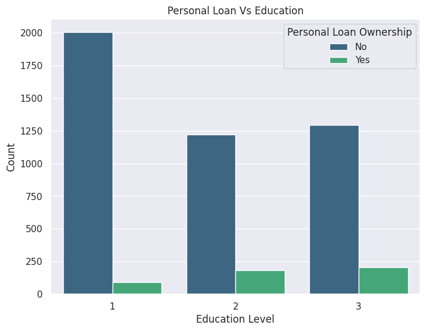

```python
#Creating a count plot to visualizing the relationship between Personal Loan Vs Education
plt.figure(figsize=(8,6))
sns.countplot(data=df,x='Education',hue='Personal_Loan',palette='viridis')
plt.xlabel('Education Level')
plt.ylabel('Count')
plt.legend(title='Personal Loan Ownership',labels=['No','Yes'],loc='upper right')
plt.title('Personal Loan Vs Education')
plt.show()
```

### Observation

- Here, As compared to Education level 1 and 2 , education level3 (Advanced and Professional) accepted more personal loan

**Q.13 What is the relation between Online Banking Vs Top 10 Zip codes?**

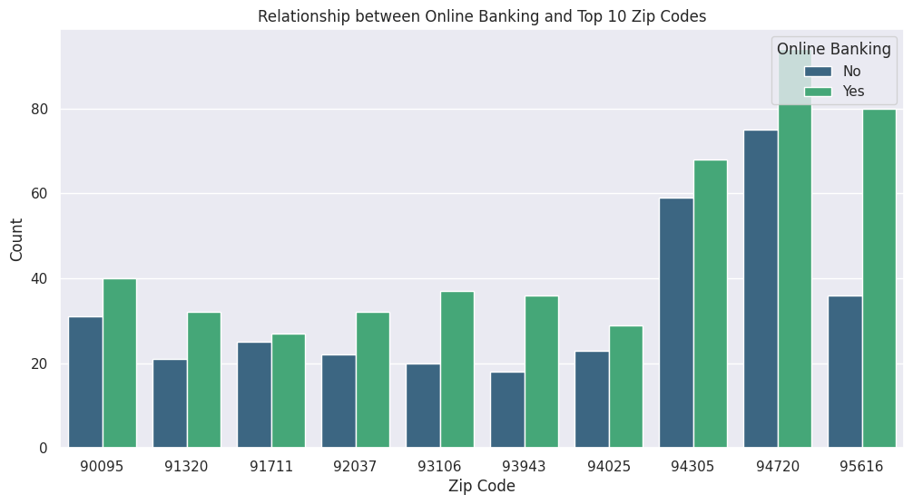

```python
# Get the top 10 Zip codes
top10_Zip_codes=df['ZIPCode'].value_counts().nlargest(10).index.tolist()
# filter the dataframe to include only top 10 zip codes
top10_df=df[df['ZIPCode'].isin(top10_Zip_codes)]

#create the countplot to visualize relationship
plt.figure(figsize=(12,6))
sns.countplot(data=top10_df,x='ZIPCode',hue='Online',palette='viridis')
plt.xlabel('Zip Code')
plt.ylabel('Count')
plt.legend(title='Online Banking',labels=['No','Yes'],loc='upper right')
plt.title('Relationship between Online Banking and Top 10 Zip Codes')
plt.show()
```

#### **Observation**

- There are three Zip codes 94305,94720,95616, who are the largest user of online banking.

**Q.14 What is the relationship between Online banking Vs Education?**

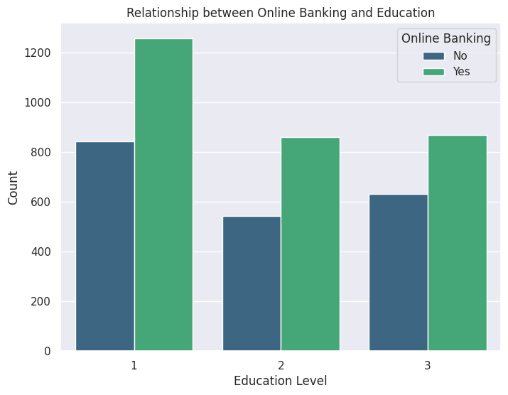

```python
# create a count plot to visualiza the relation between online and education
plt.figure(figsize=(8,6))
sns.countplot(data=df,x='Education',hue='Online',palette='viridis')
plt.title('Relationship between Online Banking and Education')
plt.xlabel('Education Level')
plt.ylabel('Count')
plt.legend(title='Online Banking',labels=['No','Yes'],loc='upper right')
plt.show()
```

### Observations

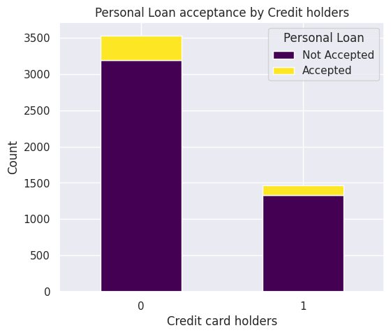

```python
#Create a crosstab to count the occurence of each personal_Loan status within Education level
education_loan_crosstab=pd.crosstab(df['CreditCard'],df['Personal_Loan'])
# Plot the  bar plot
ax=education_loan_crosstab.plot(kind='bar',stacked=True,colormap='viridis',figsize=(6,5))
plt.xlabel('Credit card holders')
plt.ylabel('Count')
plt.legend(title='Personal Loan',labels=['Not Accepted','Accepted'],loc='upper right')
plt.title('Personal Loan acceptance by Credit holders')
plt.xticks(rotation=0)
plt.show()
```

## Data Preprocessing

- Missing value treatment
- Feature engineering (if needed)
- Outlier detection and treatment (if needed)
- Preparing data for modeling
- Any other preprocessing steps (if needed)

```python
# Missing value treatment
df.isnull().sum()
```

|  | 0 |
| --- | --- |
| Age | 0 |
| Experience | 0 |
| Income | 0 |
| ZIPCode | 0 |
| Family | 0 |
| CCAvg | 0 |
| Education | 0 |
| Mortgage | 0 |
| Personal_Loan | 0 |
| Securities_Account | 0 |
| CD_Account | 0 |
| Online | 0 |
| CreditCard | 0 |
| Age_Group | 0 |

**dtype:** int64

### **Observations**

- There is no missing value in the dataset

```python
# convert Zipcode to string
df['ZIPCode']=df['ZIPCode'].astype(str)
#Extract the first two digits of ZIPCode and count unique values.
#print(df['ZIPCode'])
print("Number of unique zipcodes: ",df["ZIPCode"].str[:2].nunique(),)
# convert zip code to categorical

df['ZIPCode']=df['ZIPCode'].str[:2]
df['ZIPCode']=df['ZIPCode'].astype('category')

# change categorial feature to 'category'
category_cols=['Education',
              'Personal_Loan',
              'Securities_Account',
              'CD_Account',
              'Online',
              'CreditCard',]

df[category_cols]=df[category_cols].astype('category')
# check for the change
category_columns=df.select_dtypes(include=['category']).columns
print(category_columns)
```

```
Number of unique zipcodes:  7
Index(['ZIPCode', 'Education', 'Personal_Loan', 'Securities_Account',
       'CD_Account', 'Online', 'CreditCard', 'Age_Group'],
      dtype='object')
```

```python
#Check the unique values in the dataset
df.nunique()
```

|  | 0 |
| --- | --- |
| Age | 45 |
| Experience | 47 |
| Income | 162 |
| ZIPCode | 7 |
| Family | 4 |
| CCAvg | 108 |
| Education | 3 |
| Mortgage | 347 |
| Personal_Loan | 2 |
| Securities_Account | 2 |
| CD_Account | 2 |
| Online | 2 |
| CreditCard | 2 |
| Age_Group | 5 |

**dtype:** int64

```python
# Outlier detection using IQR
numeric_df=df.select_dtypes(include=['float64','int64'])
Q1=numeric_df.quantile(0.25)
Q3=numeric_df.quantile(0.75)
IQR=Q3-Q1
lower=(Q1-1.5*IQR)
upper=(Q3+1.5*IQR)
((numeric_df<lower)
|(numeric_df>upper)).sum()/len(df)*100
```

|  | 0 |
| --- | --- |
| Age | 0.00 |
| Experience | 0.00 |
| Income | 1.92 |
| Family | 0.00 |
| CCAvg | 6.48 |
| Mortgage | 5.82 |

**dtype:** float64

### **Obeservations**

- Credit card Avg spending, income and Mortages shows Outliers in database this probably related to very rich customer case, So we are not going to treat the outliers here.

```python
#checkig for Anamalous value

df['Education'].replace(1,'Undergrad',inplace=True)
df['Education'].replace(2,'Graduate',inplace=True)
df['Education'].replace(3,'Advanced/Professional',inplace=True)
df['Education'].unique()
```

```
['Undergrad', 'Graduate', 'Advanced/Professional']
Categories (3, object): ['Undergrad', 'Graduate', 'Advanced/Professional']
```

```python
#Check negative values in experience column
print("negative values in Experience column:"+ str(df[df['Experience']<0]['Experience'].unique()))
print("no. of negative values in Experience column:"+ str(df[df['Experience']<0]['Experience'].nunique()))

# Replace negative values in the experience column
df['Experience'].replace(-1,1, inplace=True)
df['Experience'].replace(-2,2, inplace=True)
df['Experience'].replace(-3,3, inplace=True)

print("unique values for experience:\n"+ str (df['Experience'].unique()))
print("no. of unique values for experience:\n"+ str(df['Experience'].nunique()))
```

```
negative values in Experience column:[-1 -2 -3]
no. of negative values in Experience column:3
unique values for experience:
[ 1 19 15  9  8 13 27 24 10 39  5 23 32 41 30 14 18 21 28 31 11 16 20 35
  6 25  7 12 26 37 17  2 36 29  3 22 34  0 38 40 33  4 42 43]
no. of unique values for experience:
44
```

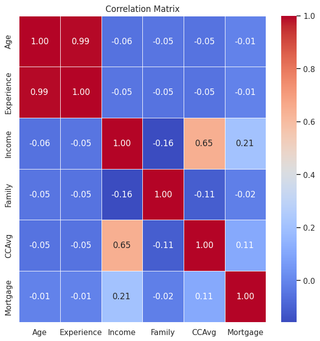

```python
#Plot the correlation matrix as a heatmap
numeric_df=df.select_dtypes(include=['float64','int64'])
plt.figure(figsize=(8,8))
sns.heatmap(numeric_df.corr(),annot=True,fmt=".2f",cmap='coolwarm', linewidths=0.5)
plt.title('Correlation Matrix')
plt.show()
```

### Observations

- Age and Experience have extremely positive correlation(0.99), you can drop either Age or Experience column.
- Income and ccAvg have moderate positive correlation(0.65)
- Income and mortgage have weak - to moderate positive correlation(0.21)
- and Most of other feature pairs (Family, mortgage with any except income) very low or near zero correlation.

**Data Prepartion**

```python
#Will drop Age_group, no need anymore
df.drop('Age_Group',axis=1,inplace=True)
```

```python
#dropping experience it's perfectly correlated with Age
x=df.drop(["Personal_Loan","Experience"],axis=1)#features
# covert Personal_Loan datatyoe into int
y=df["Personal_Loan"]#.astype(int) #Label

#separate independent and dependent variable and apply dummies on ZIPCode and Education variables
x=pd.get_dummies(x,columns=["ZIPCode","Education"])#,drop_first=True
#Note- if applying .drop_first=True then Im loosing 1st column of ZIPcode and Education, I need those columns

#spliting the data in train and test set
x_train,x_test,y_train,y_test=train_test_split(x,y,test_size=0.30,random_state=1)
```

```python
# Print the shape of training set and test set
print("Shape of training set-",x_train.shape)
print("shape of test set",x_test.shape)

#Print percentage distribution of classess
print("Percentage distribution of classes in training set:")
print(y_train.value_counts(normalize=True))
print("Percentage distribution of classes in test set:")
print(y_test.value_counts(normalize=True))
```

```
Shape of training set- (3500, 19)
shape of test set (1500, 19)
Percentage distribution of classes in training set:
Personal_Loan
0    0.905429
1    0.094571
Name: proportion, dtype: float64
Percentage distribution of classes in test set:
Personal_Loan
0    0.900667
1    0.099333
Name: proportion, dtype: float64
```

```python
x_train.head()
```

|  | Age | Income | Family | CCAvg | Mortgage | Securities_Account | CD_Account | Online | CreditCard | ZIPCode_90 | ZIPCode_91 | ZIPCode_92 | ZIPCode_93 | ZIPCode_94 | ZIPCode_95 | ZIPCode_96 | Education_Undergrad | Education_Graduate | Education_Advanced/Professional |
| --- | --- | --- | --- | --- | --- | --- | --- | --- | --- | --- | --- | --- | --- | --- | --- | --- | --- | --- | --- |
| 1334 | 47 | 35 | 2 | 1.3 | 0 | 0 | 0 | 1 | 0 | False | False | False | False | True | False | False | True | False | False |
| 4768 | 38 | 39 | 1 | 2.0 | 0 | 0 | 0 | 1 | 0 | False | False | False | True | False | False | False | False | True | False |
| 65 | 59 | 131 | 1 | 3.8 | 0 | 0 | 0 | 1 | 1 | False | True | False | False | False | False | False | True | False | False |
| 177 | 29 | 65 | 4 | 1.8 | 244 | 0 | 0 | 0 | 0 | False | False | False | False | True | False | False | False | True | False |
| 4489 | 39 | 21 | 3 | 0.2 | 0 | 0 | 0 | 1 | 0 | False | False | False | False | False | True | False | False | True | False |

## Model Building

First, lets create functions to calculate different matrix and confusion matrix , so that we dont need to use same code repeatedly for each model.

- The model_performance_classification_sklearn function will be used to check the model performance of models.
- The confusion_matrix_sklearnfunction will be used to plot confusion matrix

```python
#Defining a function compute different metrics to check performance of a classification model built using sklearn
def model_performance_classification_sklearn(model,predictor,target):
  #Predicting using independent variable
  pred=model.predict(predictor)

  acc=accuracy_score(target,pred)# to compute accuracy
  prec=precision_score(target,pred) # to compute precision
  recall=recall_score(target,pred)# to compute recall
  f1=f1_score(target,pred)# to compute f1 score

  # creating a dataframe of metrics
  df_performance=pd.DataFrame(
      {'Accuracy':acc,'Precision':prec,'Recall':recall,'F1_score':f1,},
      index=[0])
  return df_performance
```

```python
def confusion_matrix_sklearn(model,predictor,target):
  #Predicting using independent variable
  y_pred=model.predict(predictor)
  #computing confusion matrix
  cm=confusion_matrix(target,y_pred)
  labels=np.asarray(
      [
          ["{0:0.0f}".format(item)+ "\n{0:.2%}".format(item/cm.flatten().sum())]
          for item in cm.flatten()
      ]
  ).reshape(2,2)
  #Plotting confusion matrix
  plt.figure(figsize=(6,4))
  sns.heatmap(cm,annot=labels,fmt="")
  plt.xlabel("Predicted")
  plt.ylabel("Actual")
  plt.title("Confusion Matrix")
```

**DecisionTree(Default)**

```python
#Initialize the decisionTreeClassifier with the gini impurity criterian and fixed a random state
model=DecisionTreeClassifier(criterion="gini",random_state=1)
#fit the model on training data
model.fit(x_train,y_train)
```

```
DecisionTreeClassifier(random_state=1)
```

**Checkin the model performance on training data**

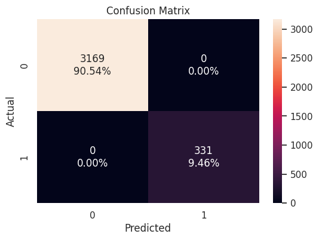

```python
confusion_matrix_sklearn(model,x_train,y_train)
```

```python
#Predict on the training data
decision_tree_perf_train=model_performance_classification_sklearn(model,x_train,y_train)
print("Performance on training data:")
decision_tree_perf_train
```

```
Performance on training data:
```

|  | Accuracy | Precision | Recall | F1_score |
| --- | --- | --- | --- | --- |
| 0 | 1.0 | 1.0 | 1.0 | 1.0 |

### Model Evaluation Criterion

```python
#Made a list of all feature variables for further use
feature_names_lst=list(x_train.columns)
print(feature_names_lst)
```

```
['Age', 'Income', 'Family', 'CCAvg', 'Mortgage', 'Securities_Account', 'CD_Account', 'Online', 'CreditCard', 'ZIPCode_90', 'ZIPCode_91', 'ZIPCode_92', 'ZIPCode_93', 'ZIPCode_94', 'ZIPCode_95', 'ZIPCode_96', 'Education_Undergrad', 'Education_Graduate', 'Education_Advanced/Professional']
```

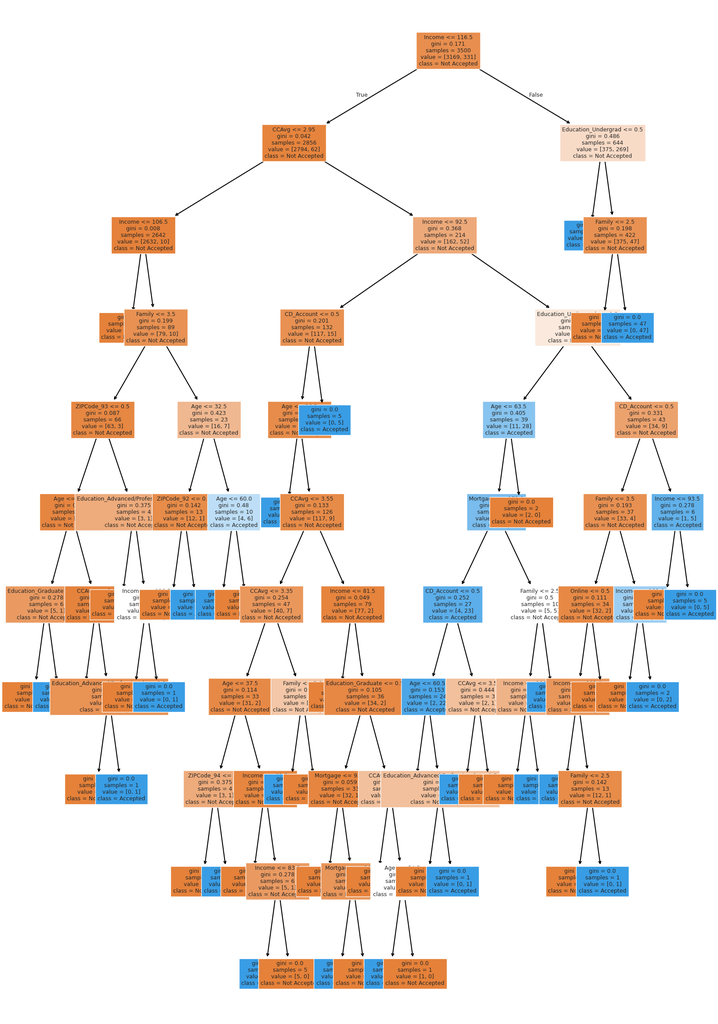

```python
#visualize the decision tree
plt.figure(figsize=(20,30))
out=tree.plot_tree(model,
                   feature_names=feature_names_lst,filled=True,
                  fontsize=9,
                  node_ids=False,
                  class_names=['Not Accepted','Accepted'])

#add arrows to decision tree split if they are missing
for o in out:
  arrow=o.arrow_patch
  if arrow is not None:
    arrow.set_edgecolor('black')
    arrow.set_linewidth(1.5)
plt.show()
```

```python
#Generate the text report showing the rules of deciosn tree
print(tree.export_text(model,feature_names=feature_names_lst,show_weights=True))
```

```
|--- Income <= 116.50
|   |--- CCAvg <= 2.95
|   |   |--- Income <= 106.50
|   |   |   |--- weights: [2553.00, 0.00] class: 0
|   |   |--- Income >  106.50
|   |   |   |--- Family <= 3.50
|   |   |   |   |--- ZIPCode_93 <= 0.50
|   |   |   |   |   |--- Age <= 28.50
|   |   |   |   |   |   |--- Education_Graduate <= 0.50
|   |   |   |   |   |   |   |--- weights: [5.00, 0.00] class: 0
|   |   |   |   |   |   |--- Education_Graduate >  0.50
|   |   |   |   |   |   |   |--- weights: [0.00, 1.00] class: 1
|   |   |   |   |   |--- Age >  28.50
|   |   |   |   |   |   |--- CCAvg <= 2.20
|   |   |   |   |   |   |   |--- weights: [48.00, 0.00] class: 0
|   |   |   |   |   |   |--- CCAvg >  2.20
|   |   |   |   |   |   |   |--- Education_Advanced/Professional <= 0.50
|   |   |   |   |   |   |   |   |--- weights: [7.00, 0.00] class: 0
|   |   |   |   |   |   |   |--- Education_Advanced/Professional >  0.50
|   |   |   |   |   |   |   |   |--- weights: [0.00, 1.00] class: 1
|   |   |   |   |--- ZIPCode_93 >  0.50
|   |   |   |   |   |--- Education_Advanced/Professional <= 0.50
|   |   |   |   |   |   |--- weights: [2.00, 0.00] class: 0
|   |   |   |   |   |--- Education_Advanced/Professional >  0.50
|   |   |   |   |   |   |--- Income <= 110.50
|   |   |   |   |   |   |   |--- weights: [1.00, 0.00] class: 0
|   |   |   |   |   |   |--- Income >  110.50
|   |   |   |   |   |   |   |--- weights: [0.00, 1.00] class: 1
|   |   |   |--- Family >  3.50
|   |   |   |   |--- Age <= 32.50
|   |   |   |   |   |--- ZIPCode_92 <= 0.50
|   |   |   |   |   |   |--- weights: [12.00, 0.00] class: 0
|   |   |   |   |   |--- ZIPCode_92 >  0.50
|   |   |   |   |   |   |--- weights: [0.00, 1.00] class: 1
|   |   |   |   |--- Age >  32.50
|   |   |   |   |   |--- Age <= 60.00
|   |   |   |   |   |   |--- weights: [0.00, 6.00] class: 1
|   |   |   |   |   |--- Age >  60.00
|   |   |   |   |   |   |--- weights: [4.00, 0.00] class: 0
|   |--- CCAvg >  2.95
```

[output cut: 90 more lines]

```
|   |   |   |   |   |   |--- Income >  102.00
|   |   |   |   |   |   |   |--- weights: [0.00, 2.00] class: 1
|   |   |   |   |--- CD_Account >  0.50
|   |   |   |   |   |--- Income <= 93.50
|   |   |   |   |   |   |--- weights: [1.00, 0.00] class: 0
|   |   |   |   |   |--- Income >  93.50
|   |   |   |   |   |   |--- weights: [0.00, 5.00] class: 1
|--- Income >  116.50
|   |--- Education_Undergrad <= 0.50
|   |   |--- weights: [0.00, 222.00] class: 1
|   |--- Education_Undergrad >  0.50
|   |   |--- Family <= 2.50
|   |   |   |--- weights: [375.00, 0.00] class: 0
|   |   |--- Family >  2.50
|   |   |   |--- weights: [0.00, 47.00] class: 1
```

```python
# importance of features in the tree building
# (normalized) total reduction of criterian brought by that feature.# Gini importance
print(
    pd.DataFrame(model.feature_importances_,columns=["Imp"],index=x_train.columns)
    .sort_values(by="Imp",ascending=False)
)
```

```
                                      Imp
Education_Undergrad              0.400952
Income                           0.315320
Family                           0.163952
CCAvg                            0.045321
Age                              0.026155
CD_Account                       0.025711
Mortgage                         0.006250
Education_Advanced/Professional  0.005978
Education_Graduate               0.003623
ZIPCode_92                       0.003080
ZIPCode_94                       0.002503
ZIPCode_93                       0.000594
Online                           0.000561
CreditCard                       0.000000
Securities_Account               0.000000
ZIPCode_91                       0.000000
ZIPCode_90                       0.000000
ZIPCode_95                       0.000000
ZIPCode_96                       0.000000
```

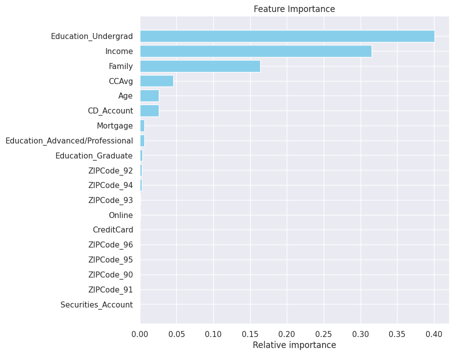

```python
#Assign the feature importance to the variable
imp=model.feature_importances_
#sort the indices in descending order
indices=np.argsort(imp)
# plot a bar for feature importances
plt.figure(figsize=(8,8))
plt.barh(range(len(indices)),imp[indices],color='skyblue',align='center')
plt.yticks(range(len(indices)),[feature_names_lst[i] for i in indices])
plt.xlabel("Relative importance")
plt.title("Feature Importance")
plt.show()
```

**Checking the model performance on Test data**

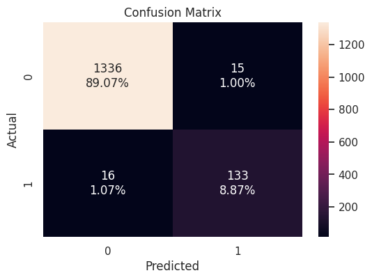

```python
# confusion matrix for test data
confusion_matrix_sklearn(model,x_test,y_test)
```

```python
# model performance on test data
decision_tree_perf_test=model_performance_classification_sklearn(model,x_test,y_test)
decision_tree_perf_test
```

|  | Accuracy | Precision | Recall | F1_score |
| --- | --- | --- | --- | --- |
| 0 | 0.979333 | 0.898649 | 0.892617 | 0.895623 |

### Observation

- The training data for Decision Tree default shows 1.0 for Accuracy, precision,recall and F1_score, it indicates that model perfectly all training samples.
- This is strong indicator of overfitting.
- and for test set, Precision , recall and F1 are close in values,indiacting balance performance, and accuracyis excellent.

**DecisionTree(on Class_weight=balanced)**

```python
# Class weight is hyperparameter for decison tree classifier
# On train data
model_1=DecisionTreeClassifier(random_state=1,class_weight="balanced")
model_1.fit(x_train,y_train)
```

```
DecisionTreeClassifier(class_weight='balanced', random_state=1)
```

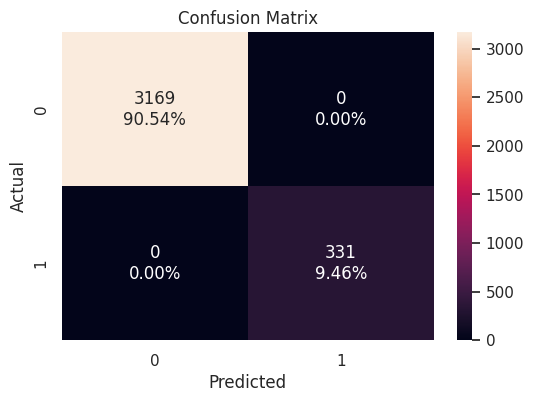

```python
# confusion matrix for class_weight
confusion_matrix_sklearn(model_1,x_train,y_train)
```

```python
decision_tree_perf_train_1=model_performance_classification_sklearn(model_1,x_train,y_train)
print("Performance on training data:")
decision_tree_perf_train_1
```

```
Performance on training data:
```

|  | Accuracy | Precision | Recall | F1_score |
| --- | --- | --- | --- | --- |
| 0 | 1.0 | 1.0 | 1.0 | 1.0 |

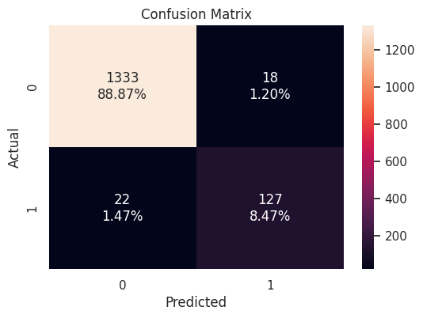

```python
# Confusion matrix On Test data
confusion_matrix_sklearn(model_1,x_test,y_test)
```

```python
decision_tree_perf_test_1=model_performance_classification_sklearn(model_1,x_test,y_test)
decision_tree_perf_test_1
```

|  | Accuracy | Precision | Recall | F1_score |
| --- | --- | --- | --- | --- |
| 0 | 0.973333 | 0.875862 | 0.852349 | 0.863946 |

### Observation

- Couldn't see much difference between DecisionTree default and Class_weight model, both performed same on Train data , but slightly different on Test data

## Pre-Pruning

```python
#choose the type of classifier
estimator=DecisionTreeClassifier(random_state=1)
#hyperparameter grid
parameters={"max_depth":np.arange(6,7),#6,7
            "min_samples_leaf":[ 7, 10],#[7,10]
            "max_leaf_nodes":[ 5, 10],#5,10
            }
# Type of scoring used to compare parameter combinations.
acc_scorer=make_scorer(recall_score)

# Run the grid search
grid_obj=GridSearchCV(estimator,parameters,scoring=acc_scorer,cv=5)
grid_obj=grid_obj.fit(x_train,y_train)

# set the clf to the best combination of parameters.
estimator = grid_obj.best_estimator_
#fit the model
estimator.fit(x_train,y_train)
```

```
DecisionTreeClassifier(max_depth=np.int64(6), max_leaf_nodes=10,
                       min_samples_leaf=7, random_state=1)
```

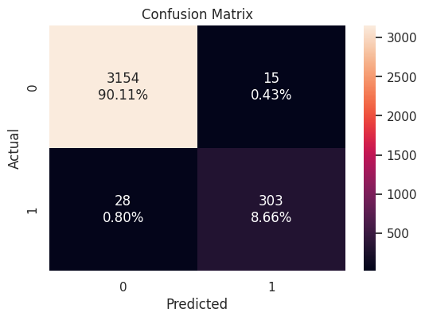

```python
#Checking performace on training data
# create confusion matrix for train data
confusion_matrix_sklearn(estimator,x_train,y_train)
```

```python
# Check performance on train data
decision_tree_tune_train=model_performance_classification_sklearn(estimator,x_train,y_train)
print("Performance on training data:")
decision_tree_tune_train
```

```
Performance on training data:
```

|  | Accuracy | Precision | Recall | F1_score |
| --- | --- | --- | --- | --- |
| 0 | 0.987714 | 0.95283 | 0.915408 | 0.933744 |

**Visualize the decision tree**

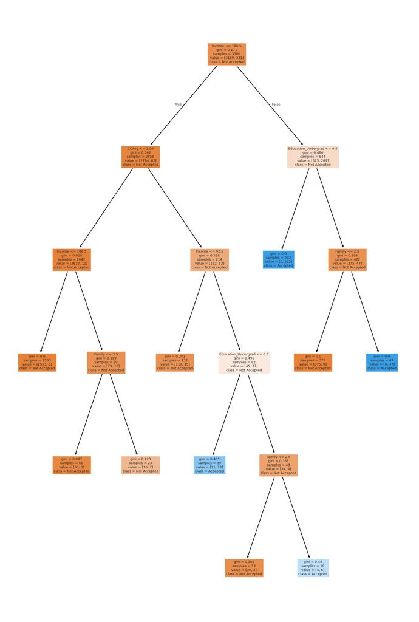

```python
# plot a Decision Tree
plt.figure(figsize=(20,30))
out=tree.plot_tree(
                    estimator,
                   feature_names=feature_names_lst,
                    filled=True,
                  fontsize=9,
                  node_ids=False,
                  class_names=['Not Accepted','Accepted'])

#add arrows to decision tree split if they are missing
for o in out:
  arrow=o.arrow_patch
  if arrow is not None:
    arrow.set_edgecolor('black')
    arrow.set_linewidth(1.5)
plt.show()
```

```python
# text report showing the rules of a decision tree
print(tree.export_text(estimator,feature_names=feature_names_lst,show_weights=True))
```

```
|--- Income <= 116.50
|   |--- CCAvg <= 2.95
|   |   |--- Income <= 106.50
|   |   |   |--- weights: [2553.00, 0.00] class: 0
|   |   |--- Income >  106.50
|   |   |   |--- Family <= 3.50
|   |   |   |   |--- weights: [63.00, 3.00] class: 0
|   |   |   |--- Family >  3.50
|   |   |   |   |--- weights: [16.00, 7.00] class: 0
|   |--- CCAvg >  2.95
|   |   |--- Income <= 92.50
|   |   |   |--- weights: [117.00, 15.00] class: 0
|   |   |--- Income >  92.50
|   |   |   |--- Education_Undergrad <= 0.50
|   |   |   |   |--- weights: [11.00, 28.00] class: 1
|   |   |   |--- Education_Undergrad >  0.50
|   |   |   |   |--- Family <= 2.50
|   |   |   |   |   |--- weights: [30.00, 3.00] class: 0
|   |   |   |   |--- Family >  2.50
|   |   |   |   |   |--- weights: [4.00, 6.00] class: 1
|--- Income >  116.50
|   |--- Education_Undergrad <= 0.50
|   |   |--- weights: [0.00, 222.00] class: 1
|   |--- Education_Undergrad >  0.50
|   |   |--- Family <= 2.50
|   |   |   |--- weights: [375.00, 0.00] class: 0
|   |   |--- Family >  2.50
|   |   |   |--- weights: [0.00, 47.00] class: 1
```

```python
# importance of features in the tree building
# (normalized) total reduction of criterian brought by that feature.# Gini importance
print(
    pd.DataFrame(estimator.feature_importances_,columns=["Imp"],index=x_train.columns)
    .sort_values(by="Imp",ascending=False)
)
```

```
                                      Imp
Education_Undergrad              0.452350
Income                           0.335994
Family                           0.169015
CCAvg                            0.042641
Age                              0.000000
Securities_Account               0.000000
Mortgage                         0.000000
Online                           0.000000
CreditCard                       0.000000
ZIPCode_90                       0.000000
CD_Account                       0.000000
ZIPCode_91                       0.000000
ZIPCode_92                       0.000000
ZIPCode_94                       0.000000
ZIPCode_93                       0.000000
ZIPCode_95                       0.000000
ZIPCode_96                       0.000000
Education_Graduate               0.000000
Education_Advanced/Professional  0.000000
```

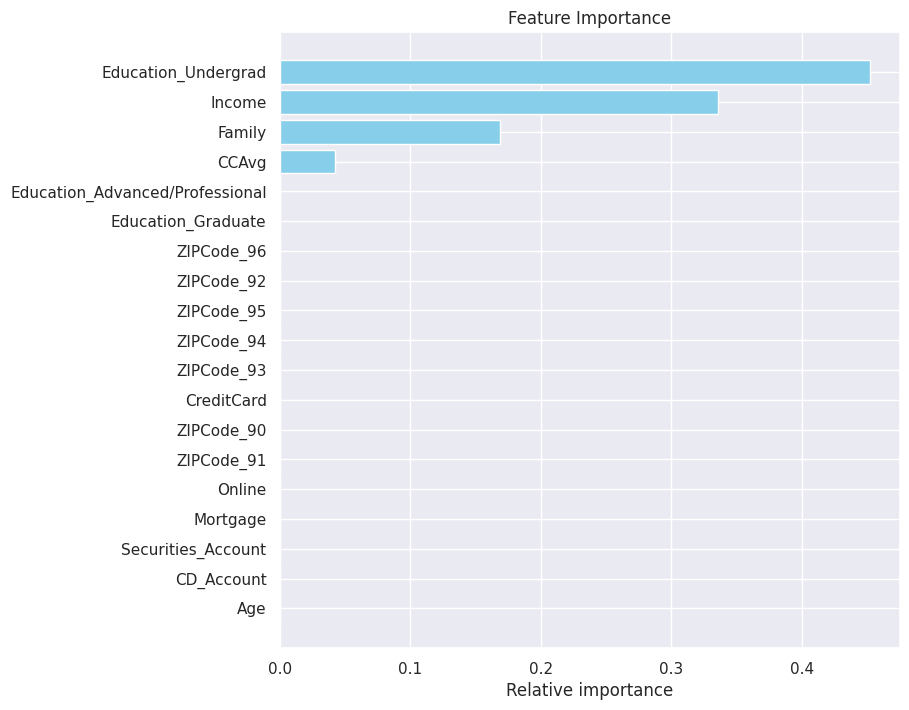

```python
importances=estimator.feature_importances_
indices=np.argsort(importances)

plt.figure(figsize=(8,8))
plt.barh(range(len(indices)),importances[indices],color='skyblue',align='center')
plt.yticks(range(len(indices)),[feature_names_lst[i] for i in indices])
plt.xlabel("Relative importance")
plt.title("Feature Importance")
plt.show()
```

**Checking the performace on the test**

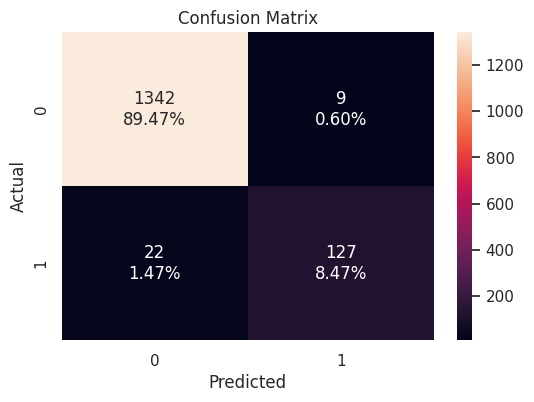

```python
#Confustion matrx on test data
confusion_matrix_sklearn(estimator,x_test,y_test)
```

```python
# model performance on test data
decision_tree_tune_test=model_performance_classification_sklearn(estimator,x_test,y_test)
decision_tree_tune_test
```

|  | Accuracy | Precision | Recall | F1_score |
| --- | --- | --- | --- | --- |
| 0 | 0.979333 | 0.933824 | 0.852349 | 0.891228 |